# Daily Study and Mood Story

Ruoyi Xu

## Introduction

This visual data story explores patterns in study habits, mood, sleep, and study environments. The data was collected using observational logging through a Google Form.

The purpose of this project is to investigate how study location and sleep may influence productivity and emotional wellbeing.

## Average Study Hours by Location

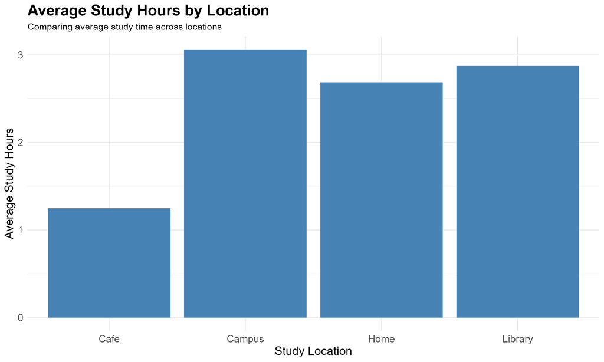

A bar chart comparing average study hours across study locations

This visualisation compares average study hours across different study locations. The results suggest that studying on campus and in the library is associated with longer study durations compared with studying at cafes or home.

## Average Mood Rating by Study Location

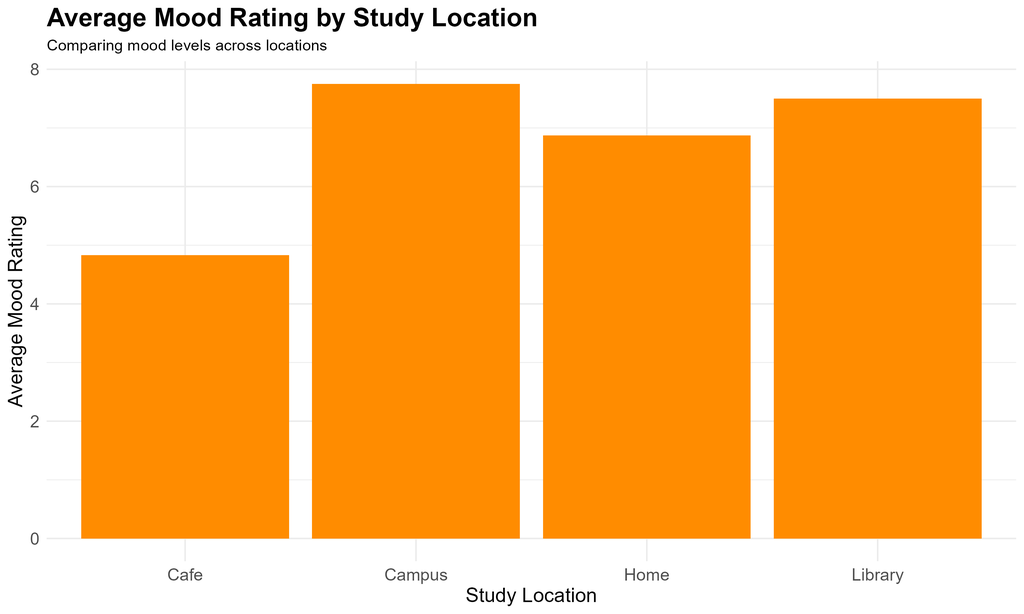

A bar chart comparing average mood ratings across study locations

This visualisation explores how mood ratings vary across study locations. Different environments may influence concentration, motivation, and emotional state.

## Relationship Between Sleep and Mood

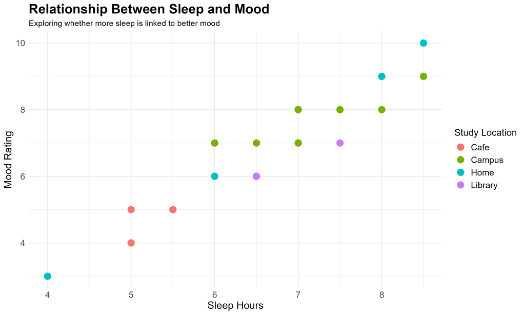

A scatter plot showing the relationship between sleep hours and mood rating

This visualisation explores the relationship between sleep duration and mood rating. The scatter plot suggests that higher sleep hours are generally associated with better mood ratings.

[figure not shown]

## Conclusion

Overall, the visualisations suggest that study environment and sleep may influence both productivity and mood. Visual storytelling makes it easier to communicate patterns and relationships in observational data.